# MATH2319 Machine Learning Project Phase 2

## Hewayalage Vishva Abeyrathne (s3735195) & Iresh Udara Kaushalya (s3704769)

### 09th June 2019

# Predicting whether a bank customer will take a loan

The main objective of this project is to perform model fitting and compare different classification models to predict whether a customer will take a loan or not using Thera bank data obtained from the Kaggle repository. The descriptive features include 6 numeric, 4 nominal categorical features and 2 ordinal categorical features. The target feature is consisted with 2 classes defined as "yes" and "no" respectively. The full dataset contains about 5K observations and it will consider for both training and testing phases.

This report is organized as follows:

- Section 2 (Overview) outlines the methodology of the project.
- Section 3 (Data Preparation) summarizes the data preparation process, feature selection criteria and briefly states model evaluation strategy.
- Section 4 (Hyperparameter Tuning) focuses the hyperparameter tuning process for all classification models.
- Section 5 (Performance Comparison) compares performance of the models.
- Section 6 (Limitations) discusses identified limitations of the approach and suggests solutions.
- Section 7 (Summary) provides a brief summary of the work related to the project.

# Overview

### Methodology

Following binary classification models will be in use for predicting the class of the target variable.

- K-Nearest Neighbors (KNN),
- Decision trees (DT), and
- Naive Bayes (NB).

Pre-processed dataset from phase 1 is used to deal with the classification tasks in this particular phase. Model building approach begins by applying transformations for the pre-processed dataset. Transformations are consisted with encoding nominal and ordinal categorical features along with scaling of descriptive features. As the first main step of our approach, the dataset split in to training and testing with a ratio 0f 70:30. With that, we have 3500 observations for training while preserving 1500 observation for test data.

Random Forest Importance method is used inside a pipeline to select the best possible features from the dataset before moving on to model fitting stage. After encoding categorical features (both nominal and ordinal), we performed feature selection with 10 and 12 (all features) features.

5-fold stratified cross-validation is used to fine-tune hyperparameters of all 3 classification models in terms of AUC performance metric with a hyperparameter search inside a pipeline. Parallel processing is selected as "-2" cores in the model building phase. Since class imbalance or the number of observations for a class are not similar (negative class has more observations than positive class), stratification is used as the part of cross-validation to ensure that both the classes have almost same proportion of observations.

After selecting the best model out of the three classification models with hyperparameter search on test data, we did 10-fold cross-validation on the test data. Then, performance of the models is assessed with the use of paired t-tests. Apart from that, evaluation strategy continues with performance matrices such as recall and precision.

# Data Preparation

## Loading Dataset

Dataset is loaded from the project directory and data types are observed to better understand the attributes. First five observations of the loaded dataset are displayed to check whether loaded data are equivalent to the source data.

```python
import pandas as pd

BankLoan_p = 'BankLoan.csv'

BankLoan = pd.read_csv(BankLoan_p, sep=',', decimal='.')

print(BankLoan.dtypes)

BankLoan.head(5)
```

```
Age                     int64
Experience              int64
Income                  int64
ZIP Code                int64
Family                 object
CCAvg                 float64
Education              object
Mortgage                int64
Personal Loan          object
Securities Account     object
CD Account             object
Online                 object
CreditCard             object
dtype: object
```

|  | Age | Experience | Income | ZIP Code | Family | CCAvg | Education | Mortgage | Personal Loan | Securities Account | CD Account | Online | CreditCard |
| --- | --- | --- | --- | --- | --- | --- | --- | --- | --- | --- | --- | --- | --- |
| 0 | 25 | 1 | 49 | 91107 | Four | 1.6 | Undergraduate | 0 | No | Yes | No | No | No |
| 1 | 45 | 19 | 34 | 90089 | Three | 1.5 | Undergraduate | 0 | No | Yes | No | No | No |
| 2 | 39 | 15 | 11 | 94720 | One | 1.0 | Undergraduate | 0 | No | No | No | No | No |
| 3 | 35 | 9 | 100 | 94112 | One | 2.7 | Graduate | 0 | No | No | No | No | No |
| 4 | 35 | 8 | 45 | 91330 | Four | 1.0 | Graduate | 0 | No | No | No | No | Yes |

Dataset consists with 5000 observations and it has 12 descriptive features and the "Personal Loan" as the target feature.

## Checking for Missing Values

It is important to make sure that there is no any missing value among all the attributes.

```python
BankLoan.isna().sum()
```

```
Age                   0
Experience            0
Income                0
ZIP Code              0
Family                0
CCAvg                 0
Education             0
Mortgage              0
Personal Loan         0
Securities Account    0
CD Account            0
Online                0
CreditCard            0
dtype: int64
```

## Summary Statistics

Summary statistics for the dataset are observed as follow.

```python
BankLoan.describe(include='all')
```

|  | Age | Experience | Income | ZIP Code | Family | CCAvg | Education | Mortgage | Personal Loan | Securities Account | CD Account | Online | CreditCard |
| --- | --- | --- | --- | --- | --- | --- | --- | --- | --- | --- | --- | --- | --- |
| count | 5000.000000 | 5000.000000 | 5000.000000 | 5000.000000 | 5000 | 5000.000000 | 5000 | 5000.000000 | 5000 | 5000 | 5000 | 5000 | 5000 |
| unique | NaN | NaN | NaN | NaN | 4 | NaN | 3 | NaN | 2 | 2 | 2 | 2 | 2 |
| top | NaN | NaN | NaN | NaN | One | NaN | Undergraduate | NaN | No | No | No | Yes | No |
| freq | NaN | NaN | NaN | NaN | 1472 | NaN | 2096 | NaN | 4520 | 4478 | 4698 | 2984 | 3530 |
| mean | 45.338400 | 20.134600 | 73.774200 | 93152.503000 | NaN | 1.937913 | NaN | 56.498800 | NaN | NaN | NaN | NaN | NaN |
| std | 11.463166 | 11.415189 | 46.033729 | 2121.852197 | NaN | 1.747666 | NaN | 101.713802 | NaN | NaN | NaN | NaN | NaN |
| min | 23.000000 | 0.000000 | 8.000000 | 9307.000000 | NaN | 0.000000 | NaN | 0.000000 | NaN | NaN | NaN | NaN | NaN |
| 25% | 35.000000 | 10.000000 | 39.000000 | 91911.000000 | NaN | 0.700000 | NaN | 0.000000 | NaN | NaN | NaN | NaN | NaN |
| 50% | 45.000000 | 20.000000 | 64.000000 | 93437.000000 | NaN | 1.500000 | NaN | 0.000000 | NaN | NaN | NaN | NaN | NaN |
| 75% | 55.000000 | 30.000000 | 98.000000 | 94608.000000 | NaN | 2.500000 | NaN | 101.000000 | NaN | NaN | NaN | NaN | NaN |
| max | 67.000000 | 43.000000 | 224.000000 | 96651.000000 | NaN | 10.000000 | NaN | 635.000000 | NaN | NaN | NaN | NaN | NaN |

## Encoding Categorical Features

Encoding of all categorical features in to numerical features including nominal and ordinal is mandatory Prior to modelling building.

### Encoding the Target Feature

"Persona Loan" feature is removed from the dataset and named it as "target", since it is the target feature. Then other features apart from target feature are named as "Data".

```python
Data = BankLoan.drop(columns='Personal Loan')
target = BankLoan['Personal Loan']
target.value_counts()
```

```
No     4520
Yes     480
Name: Personal Loan, dtype: int64
```

Target feature is encoded in a way that positive class is 1 "where it states that customer is going for the Loan".

```python
target = target.replace({'No': 0, 'Yes': 1})
target.value_counts()
```

```
0    4520
1     480
Name: Personal Loan, dtype: int64
```

It can be observed that classes are imbalanced in the target feature.

### Encoding Ordinal Categorical Features

Numeric Encoding or label encoding is used to convert two ordinal features such as "Family" and "Education" in the dataset in to numerical variables.

```python
Data['Family'] = Data['Family'].replace({'One': 1, 'Two': 2,'Three': 3, 'Four': 4})
Data['Family'].value_counts()

Data['Education'] = Data['Education'].replace({'Undergraduate': 1, 'Graduate': 2,'Advanced': 3})
Data['Education'].value_counts()
```

```
1    2096
3    1501
2    1403
Name: Education, dtype: int64
```

### Encoding Categorical Descriptive Features

One-hot coding is used here to convert all nominal categorical features in to numerical features. Further, dummy variables are defined for all those features in order to perform feature selection in next stages. "Zip Code" feature which appears to be numerical, but actually it is a nominal categorical feature. Therefore, it is also considered for encoding here as well.

```python
nominal_cols = ['ZIP Code','Securities Account','CD Account','Online','CreditCard']

for col in nominal_cols:
    n = len(Data[col].unique())
    if (n == 2):
        Data[col] = pd.get_dummies(Data[col], drop_first=True)

Data = pd.get_dummies(Data)

Data.sample(5, random_state=999)
print(Data.dtypes)
```

```
Age                     int64
Experience              int64
Income                  int64
ZIP Code                int64
Family                  int64
CCAvg                 float64
Education               int64
Mortgage                int64
Securities Account      uint8
CD Account              uint8
Online                  uint8
CreditCard              uint8
dtype: object
```

## Scaling of Features

Min-max scaling is performed for all the descriptive feature after encoding categorical features. Prior to deal with that, a copy of the dataset is taken.

```python
#Feature Scaling

from sklearn import preprocessing

Data_df = Data.copy()

Data_scaler = preprocessing.MinMaxScaler()
Data_scaler.fit(Data)
Data = Data_scaler.fit_transform(Data)
```

After the scaling, some random observations of the dataset can be observed as follow.

```python
pd.DataFrame(Data, columns=Data_df.columns).sample(5, random_state=999)
```

|  | Age | Experience | Income | ZIP Code | Family | CCAvg | Education | Mortgage | Securities Account | CD Account | Online | CreditCard |
| --- | --- | --- | --- | --- | --- | --- | --- | --- | --- | --- | --- | --- |
| 3581 | 0.113636 | 0.093023 | 0.115741 | 0.939080 | 0.666667 | 0.10 | 0.5 | 0.000000 | 0.0 | 0.0 | 0.0 | 1.0 |
| 3035 | 0.613636 | 0.558140 | 0.106481 | 0.981716 | 0.000000 | 0.03 | 1.0 | 0.000000 | 0.0 | 0.0 | 0.0 | 0.0 |
| 2455 | 0.250000 | 0.186047 | 0.722222 | 0.977892 | 1.000000 | 0.74 | 1.0 | 0.000000 | 0.0 | 0.0 | 1.0 | 0.0 |
| 3014 | 0.840909 | 0.790698 | 0.148148 | 0.938862 | 0.000000 | 0.25 | 1.0 | 0.261417 | 0.0 | 0.0 | 1.0 | 0.0 |
| 3114 | 0.136364 | 0.093023 | 0.217593 | 0.924128 | 1.000000 | 0.20 | 0.5 | 0.000000 | 1.0 | 0.0 | 1.0 | 0.0 |

## Feature Selection & Ranking

Most 10 features from the dataset are selected by Random Forest Importance (RFI) as it will identify the features which have more prediction power towards the final outcome. In the hyperparameter tuning phase, all the features will be considered to find out the best possible features works with classifiers.

```python
import numpy as np
from sklearn.ensemble import RandomForestClassifier

num_features = 12
model_rfi = RandomForestClassifier(n_estimators=100)
model_rfi.fit(Data, target)
fs_indices_rfi = np.argsort(model_rfi.feature_importances_)[::-1][0:num_features]

best_features_rfi = Data_df.columns[fs_indices_rfi].values
best_features_rfi
```

```
array(['Income', 'Education', 'CCAvg', 'Family', 'CD Account',
       'Experience', 'ZIP Code', 'Age', 'Mortgage', 'CreditCard',
       'Online', 'Securities Account'], dtype=object)
```

```python
feature_importances_rfi = model_rfi.feature_importances_[fs_indices_rfi]
feature_importances_rfi
```

```
array([0.33040087, 0.19787605, 0.14509669, 0.12047703, 0.05242219,
       0.03465263, 0.0345601 , 0.03340847, 0.03215509, 0.00817082,
       0.00662059, 0.00415947])
```

Features are displayed in an array according to the order of the RFI and "Income" feature has the most significant effect towards the final outcome out of all the features.

Significance of the features according to RFI is visualized using "Altair" package as follow.

```python
import altair as alt
alt.renderers.enable('notebook')

def plot_imp(best_features, scores, method_name, color):

    df = pd.DataFrame({'features': best_features,
                       'importances': scores})

    chart = alt.Chart(df,
                      width=500,
                      title=method_name + ' Feature Importances'
                     ).mark_bar(opacity=0.85,
                                color=color).encode(
        alt.X('features', title='Feature', sort=None, axis=alt.AxisConfig(labelAngle=45)),
        alt.Y('importances', title='Importance')
    )

    return chart
```

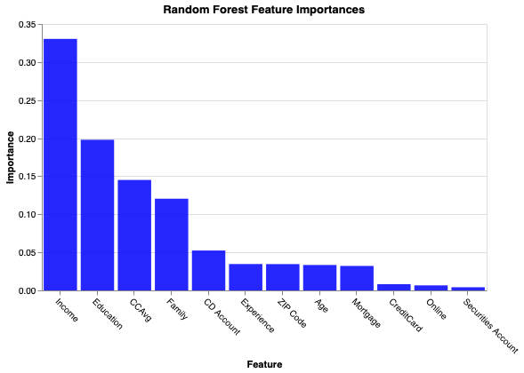

```python
plot_imp(best_features_rfi, feature_importances_rfi, 'Random Forest', 'blue')
```

It is obvious that out of all the features, "Income", "Education", "CCAvg" and "Family" have the best impact towards the final prediction outcome in order to find out whether a customer applies for a loan or not.

## Data Sampling & Train-Test Splitting

Original dataset contains 5000 rows as observations and all those observations are in use without taking a sample out of it, since the dataset is not too large.

Then dataset is split in to training data and testing data with a ratio 0f 70:30 using stratification.

```python
from sklearn.model_selection import train_test_split

Data_train, Data_test, \
target_train, target_test = train_test_split(Data,target,
                                                    test_size = 0.3, random_state=999,
                                                    stratify = target)

print(Data_train.shape)
print(Data_test.shape)
```

```
(3500, 12)
(1500, 12)
```

## Model Evaluation Strategy

As specified in the last section, 3500 rows will be in use for training whereas 1500 row are in for testing the performance of each classification model.

5-fold stratified cross-validation method will be used hyperparameter tuning.

```python
from sklearn.model_selection import StratifiedKFold, GridSearchCV

cv_method = StratifiedKFold(n_splits=5, random_state=999)
```

# Hyperparameter Tuning

## K-Nearest Neighbors (KNN)

Using `Pipeline`, we stack feature selection and grid search for KNN hyperparameter tuning via cross-validation. We will use the same `Pipeline` methodology for NB and DT.

We use `Pipeline` to perform feature selection and grid search for KNN hyperparameter tuning via cross-validation. Same `Pipeline`will be in use for other classification models as well.

Following are the KNN hyperparameters,

- the distance metric `p`.
- number of neighbours (`n_neighbors`)

Random Forest Importance (RFI) is used with 100 estimators for feature selection and it is considered as a part of the `Pipeline`

```python
from sklearn.base import BaseEstimator, TransformerMixin

# custom function for RFI feature selection inside a pipeline
# here we use n_estimators=100
class RFIFeatureSelector(BaseEstimator, TransformerMixin):

    # class constructor
    # make sure class attributes end with a "_"
    # per scikit-learn convention to avoid errors
    def __init__(self, n_features_=10):
        self.n_features_ = n_features_
        self.fs_indices_ = None

    # override the fit function
    def fit(self, X, y):
        from sklearn.ensemble import RandomForestClassifier
        from numpy import argsort
        model_rfi = RandomForestClassifier(n_estimators=100)
        model_rfi.fit(X, y)
        self.fs_indices_ = argsort(model_rfi.feature_importances_)[::-1][0:self.n_features_]
        return self

    # override the transform function
    def transform(self, X, y=None):
        return X[:, self.fs_indices_]
```

```python
from sklearn.pipeline import Pipeline
from sklearn.neighbors import KNeighborsClassifier

pipe_KNN = Pipeline(steps=[('rfi_fs', RFIFeatureSelector()),
                           ('knn', KNeighborsClassifier())])

params_pipe_KNN = {'rfi_fs__n_features_': [10, 20, Data.shape[1]],
                   'knn__n_neighbors': [1, 10, 20, 40, 60, 100],
                   'knn__p': [1, 2]}

gs_pipe_KNN = GridSearchCV(estimator=pipe_KNN,
                           param_grid=params_pipe_KNN,
                           cv=cv_method,
                           refit=True,
                           n_jobs=-2,
                           scoring='roc_auc',
                           verbose=1)
```

```python
gs_pipe_KNN.fit(Data_train, target_train);
```

```
Fitting 5 folds for each of 36 candidates, totalling 180 fits
```

```
[Parallel(n_jobs=-2)]: Using backend LokyBackend with 3 concurrent workers.
[Parallel(n_jobs=-2)]: Done  44 tasks      | elapsed:    5.8s
[Parallel(n_jobs=-2)]: Done 180 out of 180 | elapsed:   26.9s finished
```

```python
gs_pipe_KNN.best_params_
```

```
{'knn__n_neighbors': 100, 'knn__p': 1, 'rfi_fs__n_features_': 10}
```

```python
gs_pipe_KNN.best_score_
```

```
0.9696388858206282
```

It is a good practice to observe other combinations as well in order to find out whether there is a significant difference among values or not. Following function will be used to format output of the grid search as a `Pandas` data frame.

```python
# custom function to format the search results as a Pandas data frame
def get_search_results(gs):

    def model_result(scores, params):
        scores = {'mean_score': np.mean(scores),
             'std_score': np.std(scores),
             'min_score': np.min(scores),
             'max_score': np.max(scores)}
        return pd.Series({**params,**scores})

    models = []
    scores = []

    for i in range(gs.n_splits_):
        key = f"split{i}_test_score"
        r = gs.cv_results_[key]
        scores.append(r.reshape(-1,1))

    all_scores = np.hstack(scores)
    for p, s in zip(gs.cv_results_['params'], all_scores):
        models.append((model_result(s, p)))

    pipe_results = pd.concat(models, axis=1).T.sort_values(['mean_score'], ascending=False)

    columns_first = ['mean_score', 'std_score', 'max_score', 'min_score']
    columns = columns_first + [c for c in pipe_results.columns if c not in columns_first]

    return pipe_results[columns]
```

```python
results_KNN = get_search_results(gs_pipe_KNN)
results_KNN.head()
```

|  | mean_score | std_score | max_score | min_score | knn__n_neighbors | knn__p | rfi_fs__n_features_ |
| --- | --- | --- | --- | --- | --- | --- | --- |
| 30 | 0.969639 | 0.008490 | 0.981620 | 0.960278 | 100.0 | 1.0 | 10.0 |
| 26 | 0.965735 | 0.005617 | 0.972955 | 0.959228 | 60.0 | 1.0 | 12.0 |
| 25 | 0.965735 | 0.005617 | 0.972955 | 0.959228 | 60.0 | 1.0 | 20.0 |
| 18 | 0.961146 | 0.009828 | 0.969536 | 0.942672 | 40.0 | 1.0 | 10.0 |
| 32 | 0.960996 | 0.004162 | 0.964985 | 0.954407 | 100.0 | 1.0 | 12.0 |

It is obvious that there is not a much of a difference between hyperparameter combinations when it comes to feature selection. Grid search for selected 10 features is shown as follow.

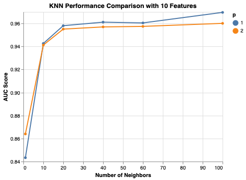

```python
import altair as alt

results_KNN_10_features = results_KNN[results_KNN['rfi_fs__n_features_'] == 10.0]

alt.Chart(results_KNN_10_features,
          title='KNN Performance Comparison with 10 Features'
         ).mark_line(point=True).encode(
    alt.X('knn__n_neighbors', title='Number of Neighbors'),
    alt.Y('mean_score', title='AUC Score', scale=alt.Scale(zero=False)),
    alt.Color('knn__p:N', title='p')
)
```

## (Gaussian) Naive Bayes (NB)

Gaussian Naive Bayes model is selected as a classification model for this particular dataset and problem. Since there is not much information regarding the dataset, we will optimize `var_smoothing` (a variant of Laplace smoothing). Default value for `var_smoothing` parameter is $10^{-9}$ and we will perform a grid search in the `logspace` starting from 10 and ending with $10^{-3}$ for 200 values over the powers of 10. But we conduct a random search by only using 20 values for shorter run times. We have to perform a power transformation on the data prior to model fitting in order to check whether that descriptive features follow a gaussian distribution as it is required Naive Bayes.

```python
from sklearn.preprocessing import PowerTransformer
Data_train_transformed = PowerTransformer().fit_transform(Data_train)
```

```python
from sklearn.naive_bayes import GaussianNB
from sklearn.model_selection import RandomizedSearchCV

pipe_NB = Pipeline([('rfi_fs', RFIFeatureSelector()),
                     ('nb', GaussianNB())])

params_pipe_NB = {'rfi_fs__n_features_': [10, 20, Data.shape[1]],
                  'nb__var_smoothing': np.logspace(1,-3, num=200)}

n_iter_search = 20
gs_pipe_NB = RandomizedSearchCV(estimator=pipe_NB,
                          param_distributions=params_pipe_NB,
                          cv=cv_method,
                          refit=True,
                          n_jobs=-2,
                          scoring='roc_auc',
                          n_iter=n_iter_search,
                          verbose=1)

gs_pipe_NB.fit(Data_train_transformed, target_train);
```

```
Fitting 5 folds for each of 20 candidates, totalling 100 fits
```

```
[Parallel(n_jobs=-2)]: Using backend LokyBackend with 3 concurrent workers.
[Parallel(n_jobs=-2)]: Done  44 tasks      | elapsed:    3.3s
[Parallel(n_jobs=-2)]: Done 100 out of 100 | elapsed:    7.3s finished
```

```python
gs_pipe_NB.best_params_
```

```
{'rfi_fs__n_features_': 10, 'nb__var_smoothing': 0.002899422853882875}
```

```python
gs_pipe_NB.best_score_
```

```
0.9451050249804359
```

NB gives an optimal AUC score of 0.945 which is slightly less than that of KNN model. But, it is not enough conclude that KNN is better than NB. For that, further tests such as paired t-test has to be considered.

```python
results_NB = get_search_results(gs_pipe_NB)
results_NB.head()
```

|  | mean_score | std_score | max_score | min_score | rfi_fs__n_features_ | nb__var_smoothing |
| --- | --- | --- | --- | --- | --- | --- |
| 17 | 0.945097 | 0.012335 | 0.958030 | 0.923342 | 10.0 | 0.002899 |
| 9 | 0.944574 | 0.012436 | 0.957322 | 0.922468 | 10.0 | 0.025529 |
| 19 | 0.941860 | 0.013990 | 0.956662 | 0.916446 | 20.0 | 0.001000 |
| 8 | 0.941860 | 0.013990 | 0.956662 | 0.916446 | 12.0 | 0.001000 |
| 2 | 0.941804 | 0.013978 | 0.956615 | 0.916423 | 20.0 | 0.001664 |

Visualisation for the search results with 10 features can be shown as follow.

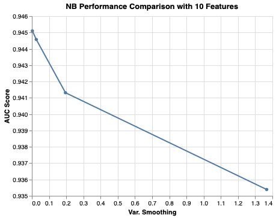

```python
results_NB_10_features = results_NB[results_NB['rfi_fs__n_features_'] == 10.0]

alt.Chart(results_NB_10_features,
          title='NB Performance Comparison with 10 Features'
         ).mark_line(point=True).encode(
    alt.X('nb__var_smoothing', title='Var. Smoothing'),
    alt.Y('mean_score', title='AUC Score', scale=alt.Scale(zero=False))
)
```

## Decision Trees (DT)

Decision Tree model is used as another classification model to make predictions. Gini index is used here and search for optimal values of depth (`max_depth`) and minimum sample split (`min_samples_split`).

```python
from sklearn.tree import DecisionTreeClassifier

pipe_DT = Pipeline([('rfi_fs', RFIFeatureSelector()),
                    ('dt', DecisionTreeClassifier(criterion='gini'))])

params_pipe_DT = {'rfi_fs__n_features_': [10, 20, Data.shape[1]],
                  'dt__max_depth': [3, 4, 5],
                  'dt__min_samples_split': [2, 5]}

gs_pipe_DT = GridSearchCV(estimator=pipe_DT,
                          param_grid=params_pipe_DT,
                          cv=cv_method,
                          refit=True,
                          n_jobs=-2,
                          scoring='roc_auc',
                          verbose=1)

gs_pipe_DT.fit(Data_train, target_train);
```

```
Fitting 5 folds for each of 18 candidates, totalling 90 fits
```

```
[Parallel(n_jobs=-2)]: Using backend LokyBackend with 3 concurrent workers.
[Parallel(n_jobs=-2)]: Done  44 tasks      | elapsed:    3.4s
[Parallel(n_jobs=-2)]: Done  90 out of  90 | elapsed:    6.9s finished
```

```python
gs_pipe_DT.best_params_
```

```
{'dt__max_depth': 3, 'dt__min_samples_split': 2, 'rfi_fs__n_features_': 10}
```

```python
gs_pipe_DT.best_score_
```

```
0.9930003817328988
```

The optimal solution of DT has a maximum depth of 3 and minimum number of splits of 2 along with ACU score of 0.993 which is highly accurate. A visualization for the search results is given below.

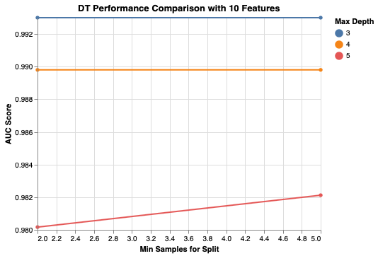

```python
results_DT = get_search_results(gs_pipe_DT)

results_DT_10_features = results_DT[results_DT['rfi_fs__n_features_'] == 10.0]

alt.Chart(results_DT_10_features,
          title='DT Performance Comparison with 10 Features'
         ).mark_line(point=True).encode(
    alt.X('dt__min_samples_split', title='Min Samples for Split'),
    alt.Y('mean_score', title='AUC Score', scale=alt.Scale(zero=False)),
    alt.Color('dt__max_depth:N', title='Max Depth')
)
```

## Further Fine Tuning

It can be observed that optimal value of maximum depth parameter is closer to the extreme end of the search. Therefore, it is better to go beyond that to make sure that there is no any better value. New search is performed as follow.

```python
params_pipe_DT2 = {'rfi_fs__n_features_': [10],
                  'dt__max_depth': [5, 10, 15],
                  'dt__min_samples_split': [5, 50, 100, 150]}

gs_pipe_DT2 = GridSearchCV(estimator=pipe_DT,
                          param_grid=params_pipe_DT2,
                          cv=cv_method,
                          refit=True,
                          n_jobs=-2,
                          scoring='roc_auc',
                          verbose=1)

gs_pipe_DT2.fit(Data_train, target_train);
```

```
Fitting 5 folds for each of 12 candidates, totalling 60 fits
```

```
[Parallel(n_jobs=-2)]: Using backend LokyBackend with 3 concurrent workers.
[Parallel(n_jobs=-2)]: Done  44 tasks      | elapsed:    3.5s
[Parallel(n_jobs=-2)]: Done  60 out of  60 | elapsed:    5.1s finished
```

```python
gs_pipe_DT2.best_params_
```

```
{'dt__max_depth': 5, 'dt__min_samples_split': 150, 'rfi_fs__n_features_': 10}
```

```python
gs_pipe_DT2.best_score_
```

```
0.9943406466387693
```

New search results suggest better parameter estimates in order to achieve slightly better results.

```python
results_DT = get_search_results(gs_pipe_DT2)
results_DT.head()
```

|  | mean_score | std_score | max_score | min_score | dt__max_depth | dt__min_samples_split | rfi_fs__n_features_ |
| --- | --- | --- | --- | --- | --- | --- | --- |
| 3 | 0.994340 | 0.002618 | 0.99789 | 0.989849 | 5.0 | 150.0 | 10.0 |
| 7 | 0.994340 | 0.002618 | 0.99789 | 0.989849 | 10.0 | 150.0 | 10.0 |
| 11 | 0.994340 | 0.002618 | 0.99789 | 0.989849 | 15.0 | 150.0 | 10.0 |
| 2 | 0.994256 | 0.002446 | 0.99789 | 0.990344 | 5.0 | 100.0 | 10.0 |
| 6 | 0.990078 | 0.008796 | 0.99789 | 0.973248 | 10.0 | 100.0 | 10.0 |

There is not much of a difference between AUC scores of different parameter combination as shown in the above table.

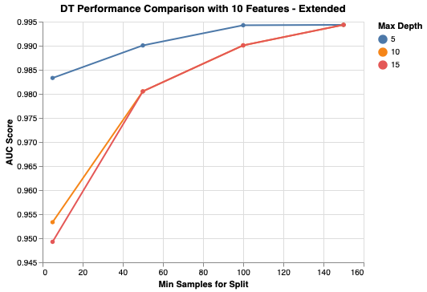

```python
results_DT_10_features = results_DT[results_DT['rfi_fs__n_features_'] == 10.0]

alt.Chart(results_DT_10_features,
          title='DT Performance Comparison with 10 Features - Extended'
         ).mark_line(point=True).encode(
    alt.X('dt__min_samples_split', title='Min Samples for Split'),
    alt.Y('mean_score', title='AUC Score', scale=alt.Scale(zero=False)),
    alt.Color('dt__max_depth:N', title='Max Depth')
)
```